# Gyro-Based UKF for Quaternion Estimation

V. Hunter Adams

##### References:

http://ancs.eng.buffalo.edu/pdf/ancs_papers/2003/uf_att.pdf

http://www.malcolmdshuster.com/Pub_1982a_C_LMS_scan.pdf

```python
from IPython.display import Latex
import matplotlib.pyplot as plt
%matplotlib inline
import numpy
from mpl_toolkits.mplot3d import Axes3D
from numpy.linalg import inv
from numpy.linalg import pinv
from scipy.stats import norm
from scipy import integrate
from numpy import random
from copy import deepcopy
from IPython.display import clear_output
from scipy.interpolate import InterpolatedUnivariateSpline
```

## The System In Question

We imagine a simple model of a CubeSat with a Kane Damper. The spacecraft must use an onboard gyroscope and optical sensors (Earth sensor, Sun sensor, Moon sensor) to determine the orientation of its angular momentum vector in an inertial frame. The spacecraft is occasionally bumped by a thruster, which reorients its angular momentum vector. This orientation can be parametrized by two angles: a rotation about the ECI $\hat{z}$ axis, and a rotation about the ECI $\hat{y}$ axis.

## Building a Model

We wish to find the equation of motion for a spacecraft tumbling through space. In order to do this, we can take the time derivative of the angular momentum vector. A vector lives outside of any coordinate system, but in this case it is easiest to write down its parametrization in the spacecraft Body frame:

\begin{align} {}^{B}{\bf{H}} = {}^{B}\begin{bmatrix}H_{x} & H_{y} & H_{z}\end{bmatrix} \cdot ^{B}\begin{bmatrix} {\bf{\hat{i}}}_{B}& {\bf{\hat{j}}}_{B}& {\bf{\hat{k}}}_{B} \end{bmatrix}^{T} \end{align}

Taking the time-derivative in an inertial frame:

\begin{align} \overset{N}{{\bf{H}}} = {}^{B}\begin{bmatrix}\dot{H}_{x} & \dot{H}_{y} & \dot{H}_{z}\end{bmatrix} \cdot ^{B}\begin{bmatrix} {\bf{\hat{i}}}_{B}& {\bf{\hat{j}}}_{B}& {\bf{\hat{k}}}_{B} \end{bmatrix}^{T} + {}^{B}\begin{bmatrix}H_{x} & H_{y} & H_{z}\end{bmatrix} \cdot ^{B}\begin{bmatrix} {\bf{\dot{\hat{i}}}}_{B}& {\bf{\dot{\hat{j}}}}_{B}& {\bf{\dot{\hat{k}}}}_{B} \end{bmatrix}^{T} = 0 \text{ (no external torques)} \end{align}

##### An Aside

Let uis assume an orthonormal set of basis vectors for the Body frame and an orthonormal set of basis vectors for the Inertial frame (a reasonable assumption). These vectors live independently of any coordinate system, and many of their properties (length and relative angles, for instance) are also independent of coordinate system. We can talk about these vectors from a particular coordinate system, and use a rotation matrix to change representations.

Let us write down the basis vectors for the inertial frame, but represented in Body frame coordinates:

\begin{align} {}^{B}{\bf{i}}_{N} = {}^{B}\begin{bmatrix} i_{x} & i_{y} & i_{z}\end{bmatrix}\cdot {}^{B}\begin{bmatrix} {\bf{\hat{i}}}_{B} & {\bf{\hat{j}}}_{B} & {\bf{\hat{k}}}_{B} \end{bmatrix}^{T}\\ {}^{B}{\bf{j}}_{N} = {}^{B}\begin{bmatrix} j_{x} & j_{y} & j_{z}\end{bmatrix}\cdot {}^{B}\begin{bmatrix} {\bf{\hat{i}}}_{B} & {\bf{\hat{j}}}_{B} & {\bf{\hat{k}}}_{B} \end{bmatrix}^{T}\\ {}^{B}{\bf{k}}_{N} = {}^{B}\begin{bmatrix} k_{x} & k_{y} & k_{z}\end{bmatrix}\cdot {}^{B}\begin{bmatrix} {\bf{\hat{i}}}_{B} & {\bf{\hat{j}}}_{B} & {\bf{\hat{k}}}_{B} \end{bmatrix}^{T} \end{align}

Since these are orthonormal unit vectors (despite the fact that they are being represented in a different frame), each is still orthogonal to each of the others and of unit length. These constraints can be written in the following way:

\begin{align} i_{x}^{2} + i_{y}^{2} + i_{z}^{2} = 1\\ j_{x}^{2} + j_{y}^{2} + j_{z}^{2} = 1\\ k_{x}^{2} + k_{y}^{2} + k_{z}^{2} = 1\\ i_{x}j_{x} + i_{y}j_{y} + i_{z}j_{z} = 0\\ i_{x}k_{x} + i_{y}k_{y} + i_{z}k_{z} = 0\\ j_{x}k_{x} + j_{y}k_{y} + j_{z}k_{z} = 0 \end{align}

It's easier to represent all of these constraints if we define the following matrix:

\begin{align} {}^{N}Q^{B} = \begin{bmatrix} i_{x} & j_{x} & k_{x}\\ i_y & j_y & k_y\\ i_z & j_z & k_z \end{bmatrix} \end{align}

Then all of the above constraints can be compactly enforced by $QQ^{T} = \mathcal{I}$. This constraint equation tells us some other information as well. By the definition of a matrix inverse, we know that $Q^{-1} = Q^{T}$. To be clear:

\begin{align} QQ^{T} = QQ^{-1} = \mathcal{I} \end{align}

$Q$ is an orthonormal matrix. It is an object that transforms a vector represented in the Body frame to an Inertial frame representation. That is to say: $^{N}{\bf{r}} = {}^{N}Q^{B}{\bf{r}}$. In practice, however, the spacecraft is rotating and the relationship between the two coordinate frames is changing with time. The Body-frame basis vectors are fixed in the Body frame, however. A more accurate equation is then:

\begin{align} {}^{N}{\bf{r}} = {}^{N}Q^{B}(t){}^{B}{\bf{r}} \end{align}

We can let ${\bf{r}} ={\bf{\hat{r}}}$, one of the Body basis vectors. Then, differentiating:

\begin{align} {}^{N}{\bf{\dot{\hat{r}}}} = \dot{Q}(t){}^{B}{\bf{r}} + Q(t)^{B}{\bf{\dot{\hat{r}}}} \end{align}

Since the Body basis vector is fixed in the Body frame, the second term goes to zero. We can insert an identity matrix inbetween the two elements of the first term in a strategic way:

\begin{align} {}^{N}{\bf{\dot{\hat{r}}}} &= \dot{Q}(t)\left[Q^{T}(t)Q(t)\right]{}^{B}{\bf{r}}\\ &= \dot{Q}(t)Q^{T}(t) {}^{N}{\bf{r}}\\ &= A{}^{N}{\bf{r}} \end{align}

where $A = \dot{Q}Q^{T}$. From before, we know that $QQ^{T} = \mathcal{I}$. Let us differentiate that equation (it will tell us some more about $A$):

\begin{align} \frac{d}{dt}\left[QQ^{T}\right] &= \dot{Q}Q^{T} + Q\dot{Q}^{T}\\ &= \dot{Q}Q^{T} + (\dot{Q}Q^{T})^{T}\\ &= A + A^{T} = 0 \end{align}

So the matrix $A$ must be antisymmetric, and the time derivative of the rotating Body basis vector is an antisymmetric matrix times that vector. We know that antisymmetric matrices are the matrix version of a cross-product. Thus, the time derivative of the unit vector is something crossed with that unit vector. What is that something?

From kinematics, we know that ${\bf{v}} = {\bf{\omega}} \times {\bf{r}}$. This is a generalization of that same equation. We have:

\begin{align} {}^{N}{\bf{\dot{\hat{r}}}} = {\bf{\omega}}^{B/N}\times{}^{B}{\bf{\hat{r}}} \end{align}

##### Back to System Dynamics

So, going back to the original angular momentum derivative:

\begin{align} \overset{N}{{\bf{H}}} &= {}^{B}\begin{bmatrix}\dot{H}_{x} & \dot{H}_{y} & \dot{H}_{z}\end{bmatrix} \cdot ^{B}\begin{bmatrix} {\bf{\hat{i}}}_{B}& {\bf{\hat{j}}}_{B}& {\bf{\hat{k}}}_{B} \end{bmatrix}^{T} + {}^{B}\begin{bmatrix}H_{x} & H_{y} & H_{z}\end{bmatrix} \cdot ^{B}\begin{bmatrix} {\bf{\dot{\hat{i}}}}_{B}& {\bf{\dot{\hat{j}}}}_{B}& {\bf{\dot{\hat{k}}}}_{B} \end{bmatrix}^{T} = 0 \text{ (no external torques)}\\ &= \overset{B}{{\bf{H}}} + ({\bf{\omega}}^{B/N} \times {}^{B}{\bf{H}}) \end{align}

Alright, so let's write down the angular momentum vector:

\begin{align} {\bf{H}}_{tot} = {\bf{h}}_{spacecraft} + {\bf{h}}_{damper} \end{align}

where:

\begin{align} {\bf{h}}_{spacecraft} &= I_{B}\cdot {\bf{\omega}}^{B/N}\\ {\bf{h}}_{damper} &= I_{D} \cdot {\bf{\omega}}^{D/N}\\ &= I_{D}\cdot \left({\bf{\omega}}^{D/B} + {\bf{\omega}}^{B/N}\right) \end{align}

In this case, the spacecraft and the damper exert a torque on one another. That torque is $\tau_{D}=c\omega^{D/B}$. This leads to a set of coupled differential equations:

\begin{align} \overset{N}{\bf{h}}_{spacecraft} &= I_{B} \cdot \dot{\omega}^{B/N} + \omega^{B/N} \times \left[I_{B} \cdot \omega^{B/N}\right] = \tau_{D} + \tau_{thruster} = c\omega^{D/B}+\tau_{thruster}\\ \overset{N}{\bf{h}}_{damper} &= I_{D} \cdot \dot{\omega}^{D/N} + \omega^{B/N} \times \left[I_{D} \cdot \omega^{D/N}\right] = -\tau_{D} = -c\omega^{D/B}\\ &= I_{D} \cdot \left(\dot{\omega}^{D/B} + \dot{\omega}^{B/N}\right) + \omega^{B/N} \times \left[ I_{D} \cdot \left(\omega^{D/B} + \omega^{B/N}\right)\right] + c\omega^{D/B} \end{align}

Solving each of the above equations:

\begin{align} \dot{\omega}^{B/N} &= -I_{B}^{-1}\left[\omega^{B/N} \times \left[I_{B} \cdot \omega^{B/N}\right] - c\omega^{D/B} + \tau_{thruster}\right]\\ \dot{\omega}^{D/B} &= -I_{D}^{-1}\left[I_{D} \cdot \dot{\omega}^{B/N} + \omega^{B/N} \times \left[ I_{D} \cdot \left(\omega^{D/B} + \omega^{B/N}\right)\right] + c\omega^{D/B}\right]\\ &= -I_{D}^{-1}\left[I_{D} \cdot \left(-I_{B}^{-1}\left[\omega^{B/N} \times \left[I_{B} \cdot \omega^{B/N}\right] - c\omega^{D/B} + \tau_{thruster}\right]\right) + \omega^{B/N} \times \left[ I_{D} \cdot \left(\omega^{D/B} + \omega^{B/N}\right)\right] + c\omega^{D/B}\right] \end{align}

We need to decide on some parameters of the problem (like inertias, etc.). Start by defining mass, height, depth, width, and inertia tensor for the Body:

```python
m = 10   #spacecraft mass, kg
h = .3   #spacecraft height, meters
w = .3   #spacecraft width, meters
d = .1   #spacecraft depth, meters
Ib = numpy.array([[(1./12.)*m*(h**2. + d**2.), 0., 0.],
                  [0., (1./12.)*m*(w**2. + d**2.), 0.],
                  [0., 0., (1./12.)*m*(w**2. + h**2.)]]) #spacecraft inertia tensor
```

Now define mass, height, radius, and inertia tensors for Kane Damper:

```python
mdamp = 8 #damper mass in kg
mrad = 0.1 #damper radius in meters
c = 0.9    #damping coefficient
Id = numpy.array([[(2./5.)*mdamp*mrad**2., 0., 0.],
                  [0., (2./5.)*mdamp*mrad**2., 0.],
                  [0., 0., (2./5.)*mdamp*mrad**2.]])
```

Initialize spacecraft quaternion and angular velocity, along with integration time, integration timestep, and standard deviation of stochastic angular accelerations:

```python
q0 = [0., 0., 0., 1.]                   # initial quaternion
omega_init = [0., 0.001, 2., 0., 0., 0.]# initial angular velocity
tstop = 700                             # total integration time
delta_t = 0.001                          # integration timestep
gyro_t = 0.04
gyrotime = numpy.arange(0, tstop, gyro_t)
sigma_acc = 0.                          # stochastic accelerations
gyro_sigma = 1.e-10
gyro_noise_sigma = 1.e-7
bias_init=[0., 0., 0.]
meas_sigma = 8.7e-4
```

Let us now define a function to integrate/propagate the spacecraft:

```python
def crs(vector):
    first = vector[0][0]
    second = vector[1][0]
    third = vector[2][0]
    return numpy.array([[0., -third, second],
                        [third, 0., -first],
                        [-second, first, 0.]])

def propagateSpacecraft(X, t):
    omegasc1, omegasc2, omegasc3 = X[0], X[1], X[2]
    omegad1, omegad2, omegad3 = X[3], X[4], X[5]
    omega_sc = numpy.array([[omegasc1, omegasc2, omegasc3]]).T
    omega_d  = numpy.array([[omegad1, omegad2, omegad3]]).T

    inner_sc = (numpy.dot(crs(omega_sc), numpy.dot(Ib, omega_sc)) - c*omega_d +
                    int(0.5*(numpy.sign(t - 100)+1))*numpy.array([[.1, 0., 0.]]).T -
                    int(0.5*(numpy.sign(t - 102)+1))*numpy.array([[.1, 0., 0.]]).T)
    omega_sc_dot = (numpy.dot(-1.*pinv(Ib), inner_sc))

    right_d = numpy.dot(crs(omega_sc), numpy.dot(Id, omega_d + omega_sc)) + c*omega_d
    inner_d = numpy.dot(Id, omega_sc_dot) + right_d
    omega_d_dot = numpy.dot(-1.*pinv(Id), inner_d)

    derivs = [omega_sc_dot[0][0], omega_sc_dot[1][0], omega_sc_dot[2][0],
              omega_d_dot[0][0], omega_d_dot[1][0], omega_d_dot[2][0]]

    return derivs

def goSpacecraft(X, tstop, delta_t):
    a_t = numpy.arange(0, tstop, delta_t)
    asol = integrate.odeint(propagateSpacecraft, X, a_t)
    hx, hy, hz = [], [], []
    htotx, htoty, htotz = [], [], []
    omegasx, omegasy, omegasz = [], [], []
    omegadx, omegady, omegadz = [], [], []
    h_norm_spacecraft = []
    hnorm = []
    for i in asol:
        omega_spacecraft = numpy.array([[i[0], i[1], i[2]]]).T
        omega_damper = numpy.array([[i[3], i[4], i[5]]]).T
        h = numpy.dot(Ib, omega_spacecraft)
        h_norm_spacecraft.extend([numpy.linalg.norm(h)])
        hdamp = numpy.dot(Id, omega_damper + omega_spacecraft)
        htot = h + hdamp
        hnorm.extend([numpy.linalg.norm(htot)])
        htotx.extend([htot[0][0]])
        htoty.extend([htot[1][0]])
        htotz.extend([htot[2][0]])
        hx.extend([h[0][0]])
        hy.extend([h[1][0]])
        hz.extend([h[2][0]])
        omegasx.extend([i[0]])
        omegasy.extend([i[1]])
        omegasz.extend([i[2]])
        omegadx.extend([i[3]])
        omegady.extend([i[4]])
        omegadz.extend([i[5]])
    return [hx, hy, hz, omegasx, omegasy, omegasz,
            omegadx, omegady, omegadz, htotx, htoty, htotz, hnorm,
            h_norm_spacecraft]

def plotSpacecraft(omega_init, tstop, delta_t):
    time = numpy.arange(0, tstop, delta_t)
    X = omega_init
    omega = goSpacecraft(X, tstop, delta_t)
    omega[0] = numpy.array(omega[0])
    omega[1] = numpy.array(omega[1])
    omega[2] = numpy.array(omega[2])
    plt.plot(time, omega[0], label='$h_{x}^{B/N}$')
    plt.plot(time, omega[1], label='$h_{y}^{B/N}$')
    plt.plot(time, omega[2], label='$h_{z}^{B/N}$')
    plt.legend(bbox_to_anchor=(1.05, 1), loc=2, borderaxespad=0.)
    plt.title('Spacecraft Angular Momentum')
    plt.xlabel('Seconds')
    plt.ylabel('Angular Momentum (SI Units)')
    plt.show()
    plt.plot(time, omega[3], label='$\omega_{x}^{B/N}$')
    plt.plot(time, omega[4], label='$\omega_{y}^{B/N}$')
    plt.plot(time, omega[5], label='$\omega_{z}^{B/N}$')
    plt.legend(bbox_to_anchor=(1.05, 1), loc=2, borderaxespad=0.)
    plt.title('Spacecraft Angular Velocity')
    plt.xlabel('Seconds')
    plt.ylabel('Rad/sec')
    plt.show()
    plt.plot(time, omega[6], label='$\omega_{x}^{D/B}$')
    plt.plot(time, omega[7], label='$\omega_{y}^{D/B}$')
    plt.plot(time, omega[8], label='$\omega_{z}^{D/B}$')
    plt.title('Damper Angular Velocity (Relative to Spacecraft)')
    plt.xlabel('Seconds')
    plt.ylabel('Rad/Sec')
    plt.legend(bbox_to_anchor=(1.05, 1), loc=2, borderaxespad=0.)
    plt.show()
    plt.plot(time, omega[9], label='$h^{tot}_{x}$')
    plt.plot(time, omega[10], label='$h^{tot}_{y}$')
    plt.plot(time, omega[11], label='$h^{tot}_{z}$')
    plt.title('Total Angular Momentum')
    plt.xlabel('Seconds')
    plt.ylabel('Angular Momentum')
    plt.legend(bbox_to_anchor=(1.05, 1), loc=2, borderaxespad=0.)
    plt.show()
    plt.plot(time, omega[12], label='$||h^{tot}||$')
    plt.title('Total Angular Momentum Norm')
    plt.xlabel('Seconds')
    plt.ylabel('Angular Momentum')
    plt.legend(bbox_to_anchor=(1.05, 1), loc=2, borderaxespad=0.)
#     plt.ylim([0.16,0.19])
    plt.show()

    return omega;
```

We now run the above propagation, giving the spacecraft a thruster kick at t=100 seconds. After the thruster kick, we expect for the spacecraft to nutate before the Kane damper damps out all angular momentum about non-max axes.

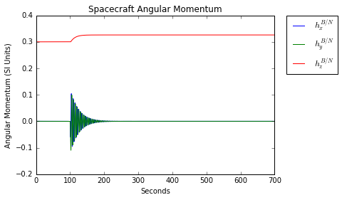

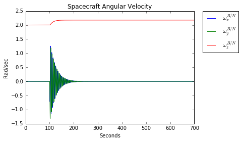

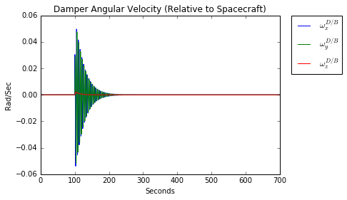

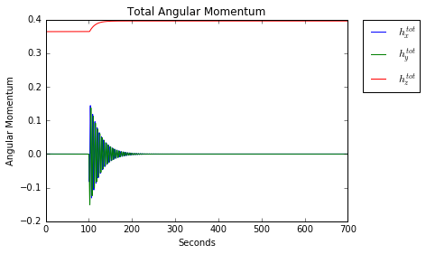

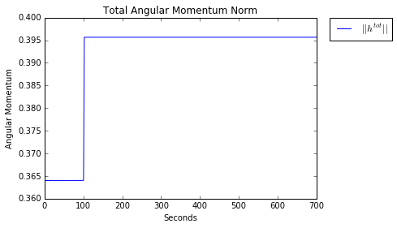

```python
angular_momentum_history = plotSpacecraft(omega_init, tstop, delta_t);
totaltime = numpy.arange(0, tstop, delta_t)
hx = InterpolatedUnivariateSpline(totaltime, angular_momentum_history[9])
hy = InterpolatedUnivariateSpline(totaltime, angular_momentum_history[10])
hz = InterpolatedUnivariateSpline(totaltime, angular_momentum_history[11])
omegax = InterpolatedUnivariateSpline(totaltime, angular_momentum_history[3])
omegay = InterpolatedUnivariateSpline(totaltime, angular_momentum_history[4])
omegaz = InterpolatedUnivariateSpline(totaltime, angular_momentum_history[5])
```

This time history can be stored in an interpolated univariate spline function, so that we can look up the angular velocity of the spacecraft at any time between 0 and tstop. The spacecraft is spinning about its maximum axis, and then it receives a large thruster pop in an orthogonal direction. The spacecraft nutates for a while before the Kane Damper damps out all nutation and it spins again about its max axis. The norm angular momentum plot shows the energy from the thruster entering the system.

The quaternion can be ascertained from the angular velocity.

\begin{align} \dot{q} &= \frac{1}{2} \omega \otimes q\\ &= \frac{1}{2}\begin{bmatrix} 0 & \omega_{x} & -\omega_y & \omega_x\\ -\omega_z & 0 & \omega_x & \omega_y\\ \omega_y & -\omega_x & 0 & \omega_z\\ -\omega_x & -\omega_y & -\omega_z & 0 \end{bmatrix}\begin{bmatrix} q_1 \\ q_2 \\ q_3 \\ q_4\end{bmatrix}\\ \dot{q}_1 &= \frac{1}{2}\left[\omega_x q_2 - \omega_y q_3 + \omega_x q_4\right]\\ \dot{q}_2 &= \frac{1}{2}\left[-\omega_z q_1 + \omega_x q_3 + \omega_y q_4\right]\\ \dot{q}_3 &=\frac{1}{2}\left[ \omega_y q_1 - \omega_x q_2 + \omega_z q_4\right]\\ \dot{q}_4 &= \frac{1}{2}\left[-\omega_x q_1 - \omega_y q_2 - \omega_z q_3\right] \end{align}

Create some functions for getting a quaternion time-history from the angular velocity time history:

```python
def propagateQuaternion(X, t):
    q1, q2, q3, q4 = X[0], X[1], X[2], X[3]
    q = numpy.array([[q1, q2, q3, q4]]).T
    ox, oy, oz = omegax(t), omegay(t), omegaz(t)
    omegacrs = numpy.array([[0., oz, -oy, ox],
                            [-oz, 0., ox, oy],
                            [oy, -ox, 0., oz],
                            [-ox, -oy, -oz, 0.]])
    qdot = .5*numpy.dot(omegacrs, q)

    return [qdot[0][0], qdot[1][0], qdot[2][0], qdot[3][0]]

def goQuaternion(X, tstop, delta_t):
    a_t = numpy.arange(0, tstop, delta_t)
    asol = integrate.odeint(propagateQuaternion, X, a_t)
    q1, q2, q3, q4 = [], [], [], []
    for i in asol:
        q1.extend([i[0]])
        q2.extend([i[1]])
        q3.extend([i[2]])
        q4.extend([i[3]])
    return [q1, q2, q3, q4]

def plotQuaternion(omega_init, tstop, delta_t, q0):
    time = numpy.arange(0, tstop, delta_t)
    X = q0
    quat = goQuaternion(X, tstop, delta_t)
    norm = numpy.sqrt(numpy.array(quat[0])**2. +
                      numpy.array(quat[1])**2. +
                      numpy.array(quat[2])**2. +
                      numpy.array(quat[3])**2.)
    plt.plot(time, norm, label='$|q|$')
    plt.plot(time, quat[0], label='$q_{1}$')
    plt.plot(time, quat[1], label='$q_{2}$')
    plt.plot(time, quat[2], label='$q_{3}$')
    plt.plot(time, quat[3], label='$q_{4}$', alpha=0.1)
    plt.legend(bbox_to_anchor=(1.05, 1), loc=2, borderaxespad=0.)
    plt.title('Spacecraft Quaternion')
    plt.xlabel('Seconds')
    plt.ylim([-1.5,1.5])
    plt.show()
    return quat;
```

This time history can be stored in an interpolated univariate spline function, so that we can look up the quaternion of the spacecraft at any time between 0 and tstop.

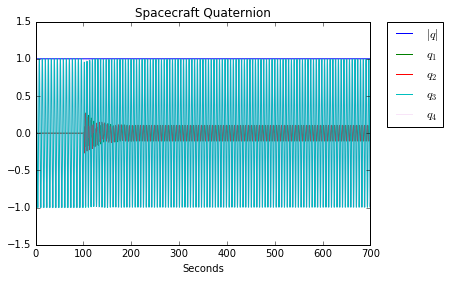

```python
quaternion_history = plotQuaternion(omega_init, tstop, delta_t, q0);
q1 = InterpolatedUnivariateSpline(totaltime, quaternion_history[0])
q2 = InterpolatedUnivariateSpline(totaltime, quaternion_history[1])
q3 = InterpolatedUnivariateSpline(totaltime, quaternion_history[2])
q4 = InterpolatedUnivariateSpline(totaltime, quaternion_history[3])
```

Incidentally, the local error-quaternion, denoted by ${\bf{\delta}}q = \begin{bmatrix}\delta \hat{q} & \delta q_{4}\end{bmatrix}$, is represented using a vector of generalized Rodrigues parameters:

\begin{align} \delta p = f\frac{\delta \hat{q}}{a + \delta q_{4}} \end{align}

where $a$ is a parameter from 0 to 1, and $f$ is a scale factor. When $a=0$ and $f=1$ then the above equation gives the Gibbs vector, and when $a=f=1$ then the quation gives the standard vector of MRP's. For small errors the attitude part of the covariance is closely related to the attitude estimation errors for any rotation sequence. We choose

\begin{align} f = 2(a+1) \end{align}

```python
a=1
f=2.*(a+1)
```

the inverse transformation from $\delta p$ to $\delta q$ is then given by:

\begin{align} \delta q_{4} &= \frac{-a||\delta p||^{2} + f\sqrt{f^2 + (1-a^2)||\delta p||^2}}{f^2 + ||\delta p||^2}\\ \delta \hat{q} &= f^{-1}(a + \delta q_4)\delta p \end{align}

## The Gyro Model

As shown above, the dynamic propagation equation for the quaternion is given by $\dot{q} = \frac{1}{2}\omega \otimes q$. If the spacecraft has a gyroscope, however, then there is a trick that one can pull.

Let us assume that the true spacecraft velocity, $\omega$, is related to the gyro output vector ${\bf{u}}$ according to

\begin{align} \omega = {\bf{u}} - {\bf{b}} - \eta_{1} \end{align}

where the vector ${\bf{b}}$ is the drift-rate bias and $\eta_{1}$ is the drift-rate noise. $\eta_{1}$ is assumed to be a Gaussian white-noise process:

\begin{align} E\left[\eta_{1}\right] = 0\\ E\left[\eta_{1}\eta_{1}^{T}\right] = Q_1 \end{align}

The drift-rate bias is not a static quantity but is driven by a second Gaussian white-noise process, the gyro drift-rate ramp noise: $\frac{d}{dt}{\bf{b}} = \eta_2$, with

\begin{align} E\left[\eta_2\right] = 0\\ E\left[\eta_2 \eta_2^T \right] = Q_2 \end{align}

The above two noise processes are assumed to be uncorrelated. These assumptions can be used to modify the quaternion propagation equation.

\begin{align} \dot{q} = \frac{1}{2}\left({\bf{u}} - {\bf{b}} - \eta_{1}\right) \otimes q \end{align}

We can use this to rewrite the dynamic propagation equations for each component of the quaternion. Originally, we had:

\begin{align} \dot{q} &= \frac{1}{2} \omega \otimes q\\ &= \frac{1}{2}\begin{bmatrix} 0 & \omega_{x} & -\omega_y & \omega_x\\ -\omega_z & 0 & \omega_x & \omega_y\\ \omega_y & -\omega_x & 0 & \omega_z\\ -\omega_x & -\omega_y & -\omega_z & 0 \end{bmatrix}\begin{bmatrix} q_1 \\ q_2 \\ q_3 \\ q_4\end{bmatrix}\\ \dot{q}_1 &= \frac{1}{2}\left[\omega_x q_2 - \omega_y q_3 + \omega_x q_4\right]\\ \dot{q}_2 &= \frac{1}{2}\left[-\omega_z q_1 + \omega_x q_3 + \omega_y q_4\right]\\ \dot{q}_3 &=\frac{1}{2}\left[ \omega_y q_1 - \omega_x q_2 + \omega_z q_4\right]\\ \dot{q}_4 &= \frac{1}{2}\left[-\omega_x q_1 - \omega_y q_2 - \omega_z q_3\right] \end{align}

Making the necessary substitutions:

\begin{align} \dot{q} &= \frac{1}{2} \left(\tilde{\omega} - {\bf{b}} - \eta_{1}\right) \otimes q \end{align}

For the dynamic propagation, we take the expected value of the above expression. Since $\eta_{1}$ is a white Gaussian process, its expected value is zero. Thus:

\begin{align} \dot{q} &= \frac{1}{2} \left(\tilde{\omega} - {\bf{b}}\right) \otimes q \end{align}

\begin{align} \dot{q}&= \frac{1}{2}\begin{bmatrix} 0 & \tilde{\omega}_{x} - b_x & -\tilde{\omega}_y + b_y & \tilde{\omega}_x - b_x\\ -\tilde{\omega}_z + b_z & 0 & \tilde{\omega}_x - b_x & \tilde{\omega}_y - b_y\\ \tilde{\omega}_y - b_y & -\tilde{\omega}_x + b_x & 0 & \tilde{\omega}_z - b_z\\ -\tilde{\omega}_x + b_x & -\tilde{\omega}_y + b_y & -\tilde{\omega}_z + b_z & 0 \end{bmatrix}\begin{bmatrix} q_1 \\ q_2 \\ q_3 \\ q_4\end{bmatrix}\\ \dot{q}_1 &= \frac{1}{2}\left[\tilde{\omega}_x q_2 - b_x q_2 - \tilde{\omega}_y q_3 + b_y q_3 + \tilde{\omega}_x q_4 - b_xq_4\right]\\ \dot{q}_2 &= \frac{1}{2}\left[-\tilde{\omega}_z q_1 + b_zq_1 + \tilde{\omega}_x q_3 - b_xq_3 + \tilde{\omega}_y q_4 - b_yq_4\right]\\ \dot{q}_3 &=\frac{1}{2}\left[ \tilde{\omega}_y q_1 - b_yq_1 - \tilde{\omega}_x q_2 + b_xq_2 + \tilde{\omega}_z q_4 - b_zq_4\right]\\ \dot{q}_4 &= \frac{1}{2}\left[-\tilde{\omega}_x q_1 + b_xq_1 - \tilde{\omega}_y q_2 + b_yq_2 - \tilde{\omega}_z q_3 + b_zq_3\right] \end{align}

And, to be explicit with the bias propagation (which is driven by a white Gaussian process):

\begin{align} \dot{b}_{x} &= 0\\ \dot{b}_{y} &= 0\\ \dot{b}_{z} &= 0 \end{align}

Putting all of this together:

\begin{align} {\bf{\dot{x}}} = \begin{bmatrix} \dot{q}_1\\ \dot{q}_2\\ \dot{q}_3\\ \dot{q}_4\\ \dot{b}_x\\ \dot{b}_y\\ \dot{b}_z\end{bmatrix} = {\bf{f}}({\bf{x}}) = \begin{bmatrix} \frac{1}{2}\left[\tilde{\omega}_x q_2 - b_x q_2 - \tilde{\omega}_y q_3 + b_y q_3 + \tilde{\omega}_x q_4 - b_xq_4\right]\\ \frac{1}{2}\left[-\tilde{\omega}_z q_1 + b_zq_1 + \tilde{\omega}_x q_3 - b_xq_3 + \tilde{\omega}_y q_4 - b_yq_4\right]\\ \frac{1}{2}\left[ \tilde{\omega}_y q_1 - b_yq_1 - \tilde{\omega}_x q_2 + b_xq_2 + \tilde{\omega}_z q_4 - b_zq_4\right]\\ \frac{1}{2}\left[-\tilde{\omega}_x q_1 + b_xq_1 - \tilde{\omega}_y q_2 + b_yq_2 - \tilde{\omega}_z q_3 + b_zq_3\right]\\0\\0\\0 \end{bmatrix} + \begin{bmatrix} 3\eta_{1} + 3\eta_{2}\\ 3\eta_{1} + 3\eta_{2}\\ 3\eta_{1} + 3\eta_{2}\\ 3\eta_{1} + 3\eta_{2}\\ \eta_{2}\\ \eta_{2}\\ \eta_{2} \end{bmatrix} \end{align}

The discrete-time equivalent of the above equation is given by (not derived here):

\begin{align} {\bf{\hat{q}}}_{k+1}^{-} = \begin{bmatrix} \cos{0.5 \Delta t ||\hat{\omega}_{k}^{+}||}\mathcal{I}_{3\times 3} - \hat{\Psi}_{k}^{+}\times & \hat{\Psi}_{k}^{+}\\ -\hat{\Psi}_{k}^{+T} & \cos{0.5\Delta t ||\hat{\omega}_{k}^{+}||} \end{bmatrix}{\bf{\hat{q}}}_{k}^{+} \end{align}

where $\Delta t$ is the sampling interval of the gyro, and

\begin{align} \Psi = \frac{\sin{0.5 \Delta t ||\hat{\omega}_{k}^{+}}||}{||\hat{\omega}_{k}^{+}||}\hat{\omega}_{k}^{+} \end{align}

```python
def propagateBias(X, t):
    bx, by, bz = X[0], X[1], X[2]
    return [numpy.random.normal(0, gyro_sigma),
            numpy.random.normal(0, gyro_sigma),
            numpy.random.normal(0, gyro_sigma)]

def goBias(X, tstop, gyro_t):
    a_t = numpy.arange(0, tstop, delta_t)
    asol = integrate.odeint(propagateBias, X, a_t)
    biasx, biasy, biasz = [], [], []
    for i in asol:
        biasx.extend([i[0]])
        biasy.extend([i[1]])
        biasz.extend([i[2]])
    return [biasx, biasy, biasz]

def plotBias(tstop, gyro_t, bias_init):
    time = numpy.arange(0, tstop, gyro_t)
    biasx, biasy, biasz = [bias_init[0]], [bias_init[1]], [bias_init[2]]
    for i in range(len(time)-1):
        xrand = sum(numpy.random.normal(0, gyro_sigma, 100))
        yrand = sum(numpy.random.normal(0, gyro_sigma, 100))
        zrand = sum(numpy.random.normal(0, gyro_sigma, 100))
        biasx.extend([biasx[-1] + xrand + numpy.random.normal(0, gyro_noise_sigma)])
        biasy.extend([biasy[-1] + yrand + numpy.random.normal(0, gyro_noise_sigma)])
        biasz.extend([biasz[-1] + zrand + numpy.random.normal(0, gyro_noise_sigma)])
    bias = [biasx, biasy, biasz]
    plt.plot(time, bias[0], label='$bias_{x}$')
    plt.plot(time, bias[1], label='$bias_{y}$')
    plt.plot(time, bias[2], label='$bias_{z}$')
    plt.legend(bbox_to_anchor=(1.05, 1), loc=2, borderaxespad=0.)
    plt.title('Gyro Bias')
    plt.xlabel('Seconds')
    plt.show()
    return bias
```

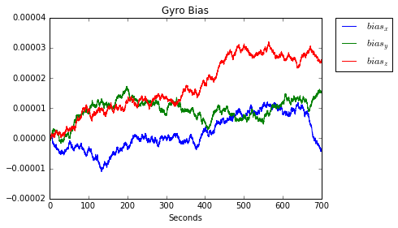

```python
bias_history = plotBias(tstop, gyro_t, bias_init);
biasx = InterpolatedUnivariateSpline(gyrotime, bias_history[0])
biasy = InterpolatedUnivariateSpline(gyrotime, bias_history[1])
biasz = InterpolatedUnivariateSpline(gyrotime, bias_history[2])
```

## Dynamic Propagation Equations

Start with $\hat{\beta}_{k}^{+}$ and $\hat{q}_{k}^{+}$, along with the gyro sampling rate. Then:

\begin{align} \hat{\omega}_{k}^{+} &= \tilde{\omega}_{k} - \hat{\beta}_{k}^{+}\\ \hat{\beta}_{k+1}^{-} &= \hat{\beta}_{k}^{+}\\ \Psi &= \frac{\sin{0.5 \Delta t ||\hat{\omega}_{k}^{+}}||}{||\hat{\omega}_{k}^{+}||}\hat{\omega}_{k}^{+}\\ {\bf{\hat{q}}}_{k+1}^{-} &= \begin{bmatrix} \cos{0.5 \Delta t ||\hat{\omega}_{k}^{+}||}\mathcal{I}_{3\times 3} - \hat{\Psi}_{k}^{+}\times & \hat{\Psi}_{k}^{+}\\ -\hat{\Psi}_{k}^{+T} & \cos{0.5\Delta t ||\hat{\omega}_{k}^{+}||} \end{bmatrix}{\bf{\hat{q}}}_{k}^{+} \end{align}

```python
def getGyroMeasurement(t, gyro_noise_sigma):
    return (numpy.array([[float(omegax(t)), float(omegay(t)),
                          float(omegaz(t))]]).T + numpy.array([[biasx(t)],
                                                               [biasy(t)],
                                                               [biasz(t)]]) +
            numpy.random.randn(3,1)*gyro_noise_sigma)

def updateOmega(t, biasEst):
    return getGyroMeasurement(t, gyro_sigma) - biasEst

def updateBeta(betakp):
    return betakp

def computePsi(t, biasEst, sample_rate):
    omegaplus = updateOmega(t, biasEst)
    return (numpy.sin(0.5*sample_rate*numpy.linalg.norm(omegaplus))/
            numpy.linalg.norm(omegaplus)) * omegaplus

def crs(vector):
    first = vector[0][0]
    second = vector[1][0]
    third = vector[2][0]
    return numpy.array([[0., -third, second],
                        [third, 0., -first],
                        [-second, first, 0.]])

def computeBigOmega(t, biasEst, sample_rate):
    psi = computePsi(t, biasEst, sample_rate)
    oneone = numpy.cos(0.5*sample_rate*numpy.linalg.norm(updateOmega(t, biasEst)))
    psicrs = crs(psi)
    lowerright = numpy.array([[numpy.cos(0.5*sample_rate*
                                         numpy.linalg.norm(updateOmega(t, biasEst)))]])
    upperleft = oneone*numpy.eye(3) - psicrs
    upperright = psi
    lowerleft = -1*psi.T
    top = numpy.concatenate((upperleft, upperright), axis=1)
    bottom = numpy.concatenate((lowerleft, lowerright), axis=1)
    return numpy.concatenate((top, bottom), axis=0)

def updateQuaternion(t, biasEst, sample_rate, qkp):
    bigO = computeBigOmega(t, biasEst, sample_rate)
    return numpy.dot(bigO, qkp)
```

Verify that we are properly riding the gyro:

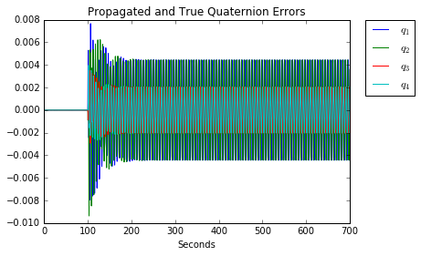

```python
def test():
    qu1, qu2 = numpy.zeros(len(gyrotime)), numpy.zeros(len(gyrotime))
    qu3, qu4 = numpy.zeros(len(gyrotime)), numpy.zeros(len(gyrotime))
    gyrox, gyroy, gyroz = numpy.zeros(len(gyrotime)), numpy.zeros(len(gyrotime)), numpy.zeros(len(gyrotime))
    quat = numpy.array([[q1(0), q2(0), q3(0), q4(0)]]).T
    qu1[0] = q1(0)
    qu2[0] = q2(0)
    qu3[0] = q3(0)
    qu4[0] = q4(0)
    counter = 1
    for i in gyrotime[0:-1]:
        if i%10 == 0:
            print i
        newq = updateQuaternion(i, numpy.array([[biasx(i), biasy(i), biasz(i)]]).T, gyro_t, quat)
        qu1[counter] = newq[0][0]
        qu2[counter] = newq[1][0]
        qu3[counter] = newq[2][0]
        qu4[counter] = newq[3][0]
        omega = getGyroMeasurement(i, gyro_noise_sigma)
        gyrox[counter] = omega[0][0]
        gyroy[counter] = omega[1][0]
        gyroz[counter] = omega[2][0]
        counter += 1
        quat = newq
    clear_output()
    norm = numpy.sqrt(numpy.array(qu1)**2. +
                      numpy.array(qu2)**2. +
                      numpy.array(qu3)**2. +
                      numpy.array(qu4)**2.)
#     plt.plot(gyrotime, norm, label='$|q|$')
    plt.plot(gyrotime, numpy.array(qu1) - q1(gyrotime), label='$q_{1}$')
    plt.plot(gyrotime, numpy.array(qu2) - q2(gyrotime), label='$q_{2}$')
    plt.plot(gyrotime, numpy.array(qu3) - q3(gyrotime), label='$q_{3}$')
    plt.plot(gyrotime, numpy.array(qu4) - q4(gyrotime), label='$q_{4}$')
    plt.legend(bbox_to_anchor=(1.05, 1), loc=2, borderaxespad=0.)
    plt.title('Propagated and True Quaternion Errors')
    plt.xlabel('Seconds')
#     plt.ylim([-1.5,1.5])
    plt.show()
    return qu1, qu2, qu3, qu4, gyrox, gyroy, gyroz

qu1, qu2, qu3, qu4, gyrox, gyroy, gyroz = test()
# print 'Uncomment to run.'
```

To within an expected amount of error, we can track the spacecraft quaternion by riding the gyroscope measurements.

## Measurement Model

The reference vectors ${\bf{r}}_{i}$ are the vectors, in an ECI frame, from the spacecraft to each celestial body. Let's assume it's December 15, 2018.

```python
satPos = numpy.array([[-15015.40312811, -23568.9768009, 2241.5049235]]).T
moonPos = numpy.array([[-22184.418543, -314381.535181, -97722.516592]]).T
sunPos = numpy.array([[-16452998.593032002, 134248022.50461, -58196377.831276014]]).T

earthVec = (-1*satPos)/numpy.linalg.norm(satPos)
moonVec = (moonPos - satPos)/numpy.linalg.norm((moonPos - satPos))
sunVec = (sunPos - satPos)/numpy.linalg.norm(sunPos - satPos)
```

The measurements are the same set of unit vectors, represented in a rotated frame. The relationship between these frames is given by the quaternion (the state of interest).

\begin{align} {\bf{z}}_{i} = A({\bf{q}}){\bf{r}}_{i} + {\bf{\nu}}_{i} \end{align}

where

\begin{align} A({\bf{q}}) &= \begin{bmatrix} 1 - 2q_2^2 - 2q_3^2 & 2q_1q_2 - 2q_3q_4 & 2q_1q_3 + 2q_2q_4\\ 2q_1q_2 + 2q_3q_4 & 1 - 2q_1^2 - 2q_3^2 & 2q_2q_3 - 2q_1q_4\\ 2q_1q_3 - 2q_2q_4 & 2q_1q_4 + 2q_2q_3 & 1 - 2q_1^2 - 2q_2^2 \end{bmatrix}\\ \nu_{i} &\sim \mathcal{N}(0,R) \end{align}

This can be bundled into the measurement model ${\bf{h}}$, which relates states to measurements. Note that these measurements are independent of gyro bias.

```python
def formA(q):
    q1, q2, q3, q4 = q[0][0], q[1][0], q[2][0], q[3][0]
    return numpy.array([[1. - 2.*q2**2. - 2.*q3**2., 2.*q1*q2 - 2.*q3*q4, 2.*q1*q3 + 2.*q2*q4],
                        [2.*q1*q2 + 2.*q3*q4, 1.-2.*q1**2. - 2.*q3**2., 2.*q2*q3 - 2.*q1*q4],
                        [2.*q1*q3 - 2.*q2*q4, 2.*q1*q4 + 2.*q2*q3, 1.-2.*q1**2. - 2.*q2**2.]])

def h(state):
    A = formA(state)
    zearth = numpy.dot(A, earthVec)
    zmoon = numpy.dot(A, moonVec)
    zsun = numpy.dot(A, sunVec)
    zearth = numpy.concatenate((zearth, zmoon), axis=0)
    zearth = numpy.concatenate((zearth, zsun), axis=0)
    return zearth
```

```python
def randomRotation(axis, angle, vector):
    A = numpy.eye(3)*numpy.cos(angle) + (1.-numpy.cos(angle))*numpy.dot(axis, axis.T) + crs(axis)*numpy.sin(angle)
    return numpy.dot(A, vector)

def getMeasurement(t, meas_sigma):
    quaternion = numpy.array([[float(q1(t))],
                              [float(q2(t))],
                              [float(q3(t))],
                              [float(q4(t))]])
    axis = numpy.random.rand(3,1)
    axis = axis/numpy.linalg.norm(axis)
    angle = meas_sigma*numpy.random.rand()
    vec = h(quaternion)
    vec[0:3][:] = randomRotation(axis, angle, vec[0:3][:])
    vec[3:6][:] = randomRotation(axis, angle, vec[3:6][:])
    vec[6:9][:] = randomRotation(axis, angle, vec[6:9][:])

    firstden = (numpy.sqrt(vec[0][0]**2. + vec[1][0]**2. + vec[2][0]**2.))
    secondden = (numpy.sqrt(vec[3][0]**2. + vec[4][0]**2. + vec[5][0]**2.))
    thirdden = (numpy.sqrt(vec[6][0]**2. + vec[7][0]**2. + vec[8][0]**2.))
    vec[0][0] = vec[0][0]/firstden
    vec[1][0] = vec[1][0]/firstden
    vec[2][0] = vec[2][0]/firstden
    vec[3][0] = vec[3][0]/secondden
    vec[4][0] = vec[4][0]/secondden
    vec[5][0] = vec[5][0]/secondden
    vec[6][0] = vec[6][0]/thirdden
    vec[7][0] = vec[7][0]/thirdden
    vec[8][0] = vec[8][0]/thirdden
    return vec

def generateMeasurementArray(tstop, dt):
    measlist = []
    for i in numpy.arange(0, tstop, dt):
        measlist.append(getMeasurement(i, meas_sigma))
    return measlist
```

```python
cameradt = 1.
measurements = generateMeasurementArray(tstop,cameradt)
```

We can plot these measurements over the course of the slew:

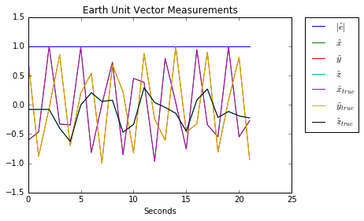

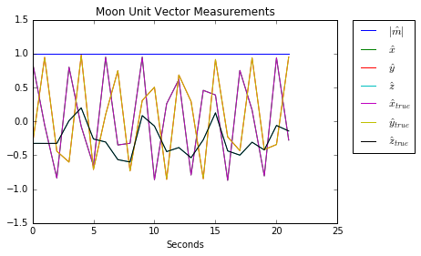

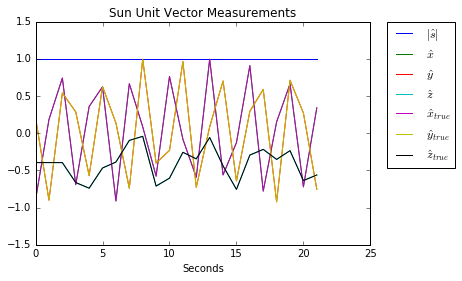

```python
def showMeas():
    ex, ey, ez, em = [], [], [], []
    my, mx, mz, mm = [], [], [], []
    sx, sy, sz, sm = [], [], [], []
    etx, ety, etz = [], [], []
    mtx, mty, mtz = [], [], []
    stx, sty, stz = [], [], []
    start = 98
    stop = 120
    counter = deepcopy(start)
    for i in measurements[start:stop]:
        em.extend([numpy.linalg.norm(i[0:3])])
        mm.extend([numpy.linalg.norm(i[3:6])])
        sm.extend([numpy.linalg.norm(i[6:9])])
        ex.extend([i[0][0]])
        ey.extend([i[1][0]])
        ez.extend([i[2][0]])
        mx.extend([i[3][0]])
        my.extend([i[4][0]])
        mz.extend([i[5][0]])
        sx.extend([i[6][0]])
        sy.extend([i[7][0]])
        sz.extend([i[8][0]])
        true = h(numpy.array([[q1(counter), q2(counter), q3(counter), q4(counter)]]).T)
        etx.extend([true[0][0]])
        ety.extend([true[1][0]])
        etz.extend([true[2][0]])
        mtx.extend([true[3][0]])
        mty.extend([true[4][0]])
        mtz.extend([true[5][0]])
        stx.extend([true[6][0]])
        sty.extend([true[7][0]])
        stz.extend([true[8][0]])
        counter +=1
    plt.plot(em, label='$|\hat{e}|$')
    plt.plot(ex, label='$\hat{x}$')
    plt.plot(ey, label='$\hat{y}$')
    plt.plot(ez, label='$\hat{z}$')
    plt.plot(etx, label='$\hat{x}_{true}$')
    plt.plot(ety, label='$\hat{y}_{true}$')
    plt.plot(etz, label='$\hat{z}_{true}$')
    plt.title('Earth Unit Vector Measurements')
    plt.xlabel('Seconds')
    plt.legend(bbox_to_anchor=(1.05, 1), loc=2, borderaxespad=0.)
    plt.ylim([-1.5,1.5])
    plt.show()
    plt.plot(mm, label='$|\hat{m}|$')
    plt.plot(mx, label='$\hat{x}$')
    plt.plot(my, label='$\hat{y}$')
    plt.plot(mz, label='$\hat{z}$')
    plt.plot(mtx, label='$\hat{x}_{true}$')
    plt.plot(mty, label='$\hat{y}_{true}$')
    plt.plot(mtz, label='$\hat{z}_{true}$')
    plt.title('Moon Unit Vector Measurements')
    plt.xlabel('Seconds')
    plt.legend(bbox_to_anchor=(1.05, 1), loc=2, borderaxespad=0.)
    plt.ylim([-1.5,1.5])
    plt.show()
    plt.plot(sm, label='$|\hat{s}|$')
    plt.plot(sx, label='$\hat{x}$')
    plt.plot(sy, label='$\hat{y}$')
    plt.plot(sz, label='$\hat{z}$')
    plt.plot(stx, label='$\hat{x}_{true}$')
    plt.plot(sty, label='$\hat{y}_{true}$')
    plt.plot(stz, label='$\hat{z}_{true}$')
    plt.title('Sun Unit Vector Measurements')
    plt.xlabel('Seconds')
    plt.legend(bbox_to_anchor=(1.05, 1), loc=2, borderaxespad=0.)
    plt.ylim([-1.5,1.5])
    plt.show()
showMeas()
```

It can be seen that the true measurements are identical to the measurements that would be expected if one were to provide the measurement model with perfect estimates of the state.

## The Unscented Kalman Filter

We begin by defining some tuning parameters. $a$ is a number generally between $10^{-4}$ and $1$ that determines the spread of the sigma points used in the Unscented KF. $\beta$ is another parameter, for which 2 is the best choice with Gaussian distributions. The paramter $\kappa$ is given by $3 - n$, where $n$ is the number of states (in this case 6 - 3 Rodrigues parameters and the gyro bias terms). The parameter $\lambda$ is given by $\lambda = \alpha^{2}\left(n + \kappa\right) - n$.

```python
# Tuning Parameters for Sigma Points
Nx = 6.                                 # number of states
alpha = 0                           # determines spread of sigma points
beta = 2.                               # optimal for Gaussian distribution
kappa = -3.                             # chosen such that kappa+Nx=3
lam = 0#alpha**2. * (kappa + Nx) - Nx     # depends on other variables
```

We begin at sample $k$ with $\hat{x}_k^+$, $P(k)$, and $Q(k)$ known a priori. We then cholesky factorize $P(k)$ and $Q(k)$ to get:

\begin{align} S(k) &= \text{chol}\left(P_k^+\right) \end{align}

```python
P0 = numpy.array([[1.e-1, 0., 0., 0., 0., 0.],
                  [0., 1.e-1, 0., 0., 0., 0.],
                  [0., 0., 1.e-1, 0., 0., 0.],
                  [0., 0., 0., 9.7e-10, 0., 0.],
                  [0., 0., 0., 0., 9.7e-10, 0.],
                  [0., 0., 0., 0., 0., 9.7e-10]]) * 10.

Q = numpy.array([[gyro_noise_sigma**2. - (1./6.)*gyro_sigma**2.*gyro_t**2., 0., 0., 0., 0., 0.],
                 [0., gyro_noise_sigma**2. - (1./6.)*gyro_sigma**2.*gyro_t**2., 0., 0., 0., 0.],
                 [0., 0., gyro_noise_sigma**2. - (1./6.)*gyro_sigma**2.*gyro_t**2., 0., 0., 0.],
                 [0., 0., 0., gyro_sigma**2., 0., 0.],
                 [0., 0., 0., 0., gyro_sigma**2., 0.],
                 [0., 0., 0., 0., 0., gyro_sigma**2.]]) * .5*gyro_t

R = numpy.eye(9) * meas_sigma**2.

x0 = numpy.array([[0., 0., 0., 0., 0., 0.]]).T

# q0 = numpy.array([[ 0.01030764,  0.01030764,  0.01030764,  0.99984062]]).T
# q0 = numpy.array([[0., 0., 0., 1.]]).T
quat = numpy.array([[numpy.random.randn(), numpy.random.randn(), numpy.random.randn(), numpy.random.randn()]]).T
q0 = quat/numpy.linalg.norm(quat)

def getCholesky(Pmat, Qmat):
    return numpy.linalg.cholesky(Pmat + Q)
```

We define the individual columns of these covariance square roots:

\begin{align} S(k) &= \begin{bmatrix}\underline{s}_{1k} & \underline{s}_{2k} & \cdots & \underline{s}_{nk}\end{bmatrix}\\ \end{align}

```python
def extractColumns(mat):
    cols = numpy.zeros((len(mat), int(Nx), 1))
    for i in range(len(mat)):
        cols[i] = (numpy.array([mat[:,i]]).T)
    return cols
```

We will use an unconstrained three-component vector to represent an attitude error quaternion (Rodriguez Parameters). Let us define the following state:

\begin{align} \chi_{k}(0) = {\bf{\hat{x}}}_{k}^{+} = \begin{bmatrix} {\bf{\delta}} \hat{p}_{k}^{+}\\ \hat{\beta}_{k}^{+} \end{bmatrix} = \begin{bmatrix} 0\\0\\0\\ \beta_{k,x}^+ \\ \beta_{k,y}^+ \\ \beta_{k,z}^+\end{bmatrix} \end{align}

this is our first sigma point. The rest of the sigma points are of the form:

\begin{align} \chi_k^{\delta p}(i) = \begin{bmatrix} \chi_k^{\delta p}(i)\\ \chi_k^{\beta}(i) \end{bmatrix} \end{align}

with

\begin{align} \chi_k(i) &= \chi_k(0) \pm \sqrt{N_x + \lambda}\underline{s}_{ik} \end{align}

This will yield $2n+1$ sigma points.

```python
def generateSigmas(xhatkp, Phatkp):
    sigpoints = numpy.zeros((int(2*Nx + 1), int(Nx), 1))
    sigpoints[0] = numpy.array([[0., 0., 0., xhatkp[3][0], xhatkp[4][0], xhatkp[5][0]]]).T
    S = getCholesky(Phatkp, Q)
    si = extractColumns(S)
    counter = 1
    for i in si:
        sigpoints[counter] = (sigpoints[0] + numpy.sqrt(Nx+lam)*i)
        sigpoints[counter+1] = (sigpoints[0] - numpy.sqrt(Nx+lam)*i)
        counter+=2
    return sigpoints
```

where the top part is from the attitude-error, and the bottom part is from the gyro bias. To describe $\chi_k^{\delta p}$ we first define a new quaternion generated by multiplying an error quaternion by the current estimate. We assume:

\begin{align} \hat{q}_k(0) &= \hat{q}_k^+\\ \hat{q}_k^+(i) &= \delta q_k^+(i)\otimes \hat{q}_k^+ \end{align}

for $i=1,\dots,2n$, and where $\delta q_k^+(i) = \begin{bmatrix}\delta \hat{q}^+(i) & \delta{q}_4^+(i)\end{bmatrix}^T$, given by the equations below:

\begin{align} \delta q_{4_{k}}^+ &= \frac{-a||\chi_{k}^{\delta p}(i)||^{2} + f\sqrt{f^2 + (1-a^2)||\chi_{k}^{\delta p}(i)||^2}}{f^2 + ||\chi_{k}^{\delta p}(i)||^2}\\ \delta \hat{q}_k^+ &= f^{-1}(a + \delta q_4)\chi_{k}^{\delta p}(i) \end{align}

```python
def makeErrorQuaternion(sigmas):
    errorquat = numpy.zeros((len(sigmas), 4, 1))
    counter = 0
    for i in sigmas:
        deltap = numpy.array([[i[0][0], i[1][0], i[2][0]]]).T
        deltaq4p = ((-a*numpy.linalg.norm(deltap)**2. +
                     f*numpy.sqrt(f**2. + (1-a**2.)*numpy.linalg.norm(deltap)**2.))/
                    (f**2. + numpy.linalg.norm(deltap)**2.))
        deltaqhatkp = (1./f)*(a + deltaq4p)*deltap
        deltaq = numpy.concatenate((deltaqhatkp, numpy.array([[deltaq4p]])), axis=0)
        deltaq = deltaq/numpy.linalg.norm(deltaq)
        errorquat[counter] = deltaq
        counter += 1
    return errorquat
```

These quaternion errors are used to perturb the existing quaternion estimate.

\begin{align} \hat{q}_k^+(0) &= \hat{q}_k^+\\ \hat{q}_k^+(i) &= \delta q_k^+(i) \otimes \hat{q}_k^+ \end{align}

```python
def quaternionComposition(firstq, secondq):
    q1, q2, q3, q4 = firstq[0][0], firstq[1][0], firstq[2][0], firstq[3][0]
    mat = numpy.array([[q4, q3, -q2, q1],
                       [-q3, q4, q1, q2],
                       [q2, -q1, q4, q3],
                       [-q1, -q2, -q3, q4]])
    return numpy.dot(mat, secondq)

def perturbQuaternionEstimate(errorquat, qhatk):
    newquats = numpy.zeros((len(errorquat), 4, 1))
    counter = 0
    for i in errorquat:
        new = quaternionComposition(i, qhatk)
        new = new/numpy.linalg.norm(new)
        newquats[counter] = (new)
        counter += 1
    return newquats
```

Each of the updated quaternions is then propagated forward using the dynamic propagation equation that we've already derived. Note that the propagation equation depends on the gyro bias. Each sigma point has a different quaternion and a different gyro bias.

\begin{align} \hat{\omega}_{k}^{+} &= \tilde{\omega}_{k} - \hat{\beta}_{k}^{+}\\ \hat{\beta}_{k+1}^{-} &= \hat{\beta}_{k}^{+}\\ \Psi &= \frac{\sin{0.5 \Delta t ||\hat{\omega}_{k}^{+}}||}{||\hat{\omega}_{k}^{+}||}\hat{\omega}_{k}^{+}\\ {\bf{\hat{q}}}_{k+1}^{-} &= \begin{bmatrix} \cos{0.5 \Delta t ||\hat{\omega}_{k}^{+}||}\mathcal{I}_{3\times 3} - \hat{\Psi}_{k}^{+}\times & \hat{\Psi}_{k}^{+}\\ -\hat{\Psi}_{k}^{+T} & \cos{0.5\Delta t ||\hat{\omega}_{k}^{+}||} \end{bmatrix}{\bf{\hat{q}}}_{k}^{+} \end{align}

```python
def propagateQuaternion(perturbed_quat_list, sigmas, t):
    time = numpy.arange(t, t+cameradt, gyro_t)
    updated_quats = numpy.zeros((len(perturbed_quat_list), 4, 1))
    for i in range(len(perturbed_quat_list)):
        bias = numpy.array([[sigmas[i][3][0], sigmas[i][4][0], sigmas[i][5][0]]]).T
        quat = perturbed_quat_list[i]
        for j in time:
            newq = updateQuaternion(j, bias, gyro_t, quat)
            newq = newq/numpy.linalg.norm(newq)
            quat = newq
        updated_quats[i] = (quat)
    return updated_quats
```

The propagated error quaternions are computed using:

\begin{align} \delta{q}_{k+1}^-(i) &= q_{k+1}^-(i)\otimes \left[\hat{q}_{k+1}^-(0)\right]^{-1} \end{align}

```python
def quaternionInv(quat):
    return numpy.array([[-1*quat[0][0]],
                        [-1*quat[1][0]],
                        [-1*quat[2][0]],
                        [ 1*quat[3][0]]])
```

```python
def propagatedQuaternionError(newquats):
    errorprop = numpy.zeros((len(newquats), 4, 1))
    invquat = quaternionInv(newquats[0])
    counter = 0
    for i in newquats:
        err = quaternionComposition(i, invquat)
        err = err/numpy.linalg.norm(err)
        errorprop[counter] = (err)
        counter += 1
    return errorprop
```

From here, the propagated sigma points can be calculated using:

\begin{align} \chi_{k+1}^{\delta p}(0) &= \underline{0}\\ \chi_{k+1}^{\delta p}(i) &= f\frac{\delta \hat{q}_{k+1}^-(k)}{a + \delta q_{4_{k+1}}(i)}\\ \chi_{k+1}^{\beta}(i) &= \chi_{k}^{\beta}(i) \end{align}

```python
def recoverPropSigma(quat_errors, old_sigmas):
    newsigs = numpy.zeros((len(quat_errors), int(Nx), 1))
    for i in range(len(quat_errors)):
        deltaqhat = numpy.array([[quat_errors[i][0][0]],
                                 [quat_errors[i][1][0]],
                                 [quat_errors[i][2][0]]])
        deltaq4 = quat_errors[i][3][0]
        top = (f*deltaqhat)/(a + deltaq4)
        bottom = numpy.array([[old_sigmas[i][3][0]],
                              [old_sigmas[i][4][0]],
                              [old_sigmas[i][5][0]]])
        sig = numpy.concatenate((top, bottom), axis=0)
        newsigs[i]=(sig)
    return newsigs
```

With these propagated sigma points, we can compute the predicted mean and covariance using the below equations:

\begin{align} \hat{x}_{k+1}^{-} &= \frac{1}{n+\lambda} \left\{\lambda \chi_{k+1}(0) + \frac{1}{2}\sum_{i=1}^{2n}\chi_{k+1}(i)\right\}\\ P_{k+1}^{-} &= \frac{1}{n+\lambda}\left\{\lambda\left[\chi_{k+1}(0) - \hat{x}_{k+1}^{-}\right]\left[\chi_{k+1}(0) - \hat{x}_{k+1}^{-}\right]^{T} + \frac{1}{2}\sum_{i=1}^{2n}\left[\chi_{k+1}(i) - \hat{x}_{k+1}^{-}\right]\left[\chi_{k+1}(i) - \hat{x}_{k+1}^{-}\right]^{T} \right\} + Q \end{align}

```python
def predictedMean(newsigs):
    xmean = (1./(Nx + lam))*(lam*newsigs[0])
    for i in newsigs[1:]:
        xmean += (1./(2.*(Nx+lam)))*i
    return xmean

def predictedCov(newsigs, pred_mean):
    P = ((lam/(Nx + lam)))*numpy.dot((newsigs[0] - pred_mean),(newsigs[0] - pred_mean).T)
    for i in newsigs[1:]:
        P += (1./(2*(Nx+lam)))*numpy.dot((i - pred_mean), (i - pred_mean).T)
    return P + Q
```

We can then calculate the mean observations using:

\begin{align} \hat{z}_{k+1}^- = \frac{1}{n+\lambda}\left\{\lambda {\bf{h}}(\chi_{k+1}(0)) + \frac{1}{2}\sum_{i=1}^{2n}{\bf{h}}(\chi_{k+1}(i))\right\} \end{align}

```python
def hFromSigs(prop_quaternions):
    hlist = numpy.zeros((len(prop_quaternions), 9, 1))
    counter = 0
    for i in prop_quaternions:
        hlist[counter] = (h(i))
        counter +=1
    return hlist

def meanMeasurement(hlist):
    zmean = (1./(Nx + lam))*(lam * hlist[0])
    for i in hlist[1:]:
        zmean += (1./(2*(Nx+lam)))*i
    firstden = numpy.sqrt(zmean[0][0]**2. + zmean[1][0]**2. + zmean[2][0]**2.)
    secondden = numpy.sqrt(zmean[3][0]**2. + zmean[4][0]**2. + zmean[5][0]**2.)
    thirdden = numpy.sqrt(zmean[6][0]**2. + zmean[7][0]**2. + zmean[8][0]**2.)
    zmean[0][0] = zmean[0][0]/firstden
    zmean[1][0] = zmean[1][0]/firstden
    zmean[2][0] = zmean[2][0]/firstden
    zmean[3][0] = zmean[3][0]/secondden
    zmean[4][0] = zmean[4][0]/secondden
    zmean[5][0] = zmean[5][0]/secondden
    zmean[6][0] = zmean[6][0]/thirdden
    zmean[7][0] = zmean[7][0]/thirdden
    zmean[8][0] = zmean[8][0]/thirdden
    return zmean
```

The output covariance is then given by:

\begin{align} P_{k+1}^{zz} = \frac{1}{n+\lambda}\left\{\lambda\left[{\bf{h}}(\chi_{k+1}(0)) - \hat{z}_{k+1}^-\right]\left[{\bf{h}}(\chi_{k+1}(0)) - \hat{z}_{k+1}^-\right]^{T} + \frac{1}{2}\sum_{i=1}^{2n}\left[{\bf{h}}(\chi_{k+1}(i) - \hat{z}_{k+1}^-\right]\left[{\bf{h}}(\chi_{k+1}(i) - \hat{z}_{k+1}^-\right]^{T}\right\} + R \end{align}

```python
def Pzz(hlist, zmean):
    Pzz = ((lam/(Nx+lam)))*numpy.dot(hlist[0] - zmean, (hlist[0] - zmean).T)
    for i in hlist[1:]:
        Pzz += (1./(2*(Nx+lam)))*numpy.dot(i-zmean, (i-zmean).T)
    return Pzz + R
```

And the cross-correlation matrix is given by:

\begin{align} P_{k+1}^{xz} &= \frac{1}{n+\lambda} \left\{\lambda \left[\chi_{k+1}(0) - \hat{x}_{k+1}^-\right]\left[{\bf{h}}(\chi_{k+1}(0)) - \hat{z}_{k+1}^-\right]^{T} + \frac{1}{2}\sum_{i=1}^{2n}\left[\chi_{k+1}(i) - \hat{x}_{k+1}^{-}\right]\left[{\bf{h}}(\chi_{k+1}(i)) - \hat{z}_{k+1}^{-}\right]^{T}\right\} \end{align}

```python
def Pxz(siglist, xmean, hlist, zmean):
    Pxzmat = ((lam/(Nx+lam)))*numpy.dot(siglist[0] - xmean, (hlist[0]-zmean).T)
    for i in range(1,len(siglist)):
        Pxzmat += (1./(2*(Nx+lam)))*numpy.dot(siglist[i]-xmean,(hlist[i]-zmean).T)
    return Pxzmat
```

The above covariances can be used to calculate the Kalman gain:

\begin{align} K = P_{xz}P_{zz}^{-1} \end{align}

```python
def getGain(Pxzmat,Pzzmat):
    return numpy.dot(Pxzmat, pinv(Pzzmat))
```

Finally, the state and covariance are updated:

\begin{align} \hat{x}_k^+ &= \hat{x}_k^- + P_{xz}P_{zz}^{-1}\left[\underline{z}(k+1) - \underline{\overline{z}}(k+1)\right]\\ P_k^+ &= P_k^- -K(k+1)P_{zz}(k+1)K(k+1)^T \end{align}

```python
def updateXhat(xmean, K, measurement, zmean):
    inner = measurement - zmean
    right = numpy.dot(K, inner)
    return xmean + right

def updatePhat(Pmean, K, Pzzmat):
    return Pmean - numpy.dot(numpy.dot(K, Pzzmat), K.T)
```

The quaternion is then updated using $\hat{q}_{k+1}^+ = \delta q_{k+1}^{+} \otimes \hat{q}_{k+1}^-(0)$, where $\delta q_{k+1}^{+} = \begin{bmatrix}\delta \hat{q}_{k+1}^+ & \delta q_{4_{k+1}}^+\end{bmatrix}^{T}$, given below:

\begin{align} \delta q_{4_{k+1}}^+ &= \frac{-a||\delta \hat{p}_{k+1}^+||^{2} + f\sqrt{f^2 + (1-a^2)||\delta \hat{p}_{k+1}^+||^2}}{f^2 + ||\delta \hat{p}_{k+1}^+||^2}\\ \delta \hat{q}^+_{k+1} &= f^{-1}(a + \delta q_{4_{k+1}}^+)\delta \hat{p}_{k+1}^+ \end{align}

```python
def updateQuaternionEstimate(xhatkp, qhatkm):
    i = xhatkp
    deltap = numpy.array([[i[0][0], i[1][0], i[2][0]]]).T
    deltaq4p = ((-a*numpy.linalg.norm(deltap)**2. +
                 f*numpy.sqrt(f**2. + (1-a**2.)*numpy.linalg.norm(deltap)**2.))/
                (f**2. + numpy.linalg.norm(deltap)**2.))
    deltaqhatkp = (1./f)*(a + deltaq4p)*deltap
    deltaq = numpy.concatenate((deltaqhatkp, numpy.array([[deltaq4p]])), axis=0)
    new = quaternionComposition(deltaq, qhatkm)
    return new/numpy.linalg.norm(new)
```

Finally, $\delta \hat{p}_{k+1}^+$ is reset to zero for the next propagation.

```python
def resetSigmaSeed(xhatkp):
    return numpy.array([[0., 0., 0., xhatkp[3][0], xhatkp[4][0], xhatkp[5][0]]]).T
```

Bundle all of this up into a UKF:

```python
sigmas = generateSigmas(x0, P0)
err_quats = makeErrorQuaternion(sigmas)
quat_pert = perturbQuaternionEstimate(err_quats,q0)
prop_quat = propagateQuaternion(quat_pert, sigmas, 0)
quat_errors = propagatedQuaternionError(prop_quat)
new_sigs = recoverPropSigma(quat_errors, sigmas)
pred_mean = predictedMean(new_sigs)
pred_cov = predictedCov(new_sigs, pred_mean)
hlist = hFromSigs(prop_quat)
zmean = meanMeasurement(hlist)
Pzzmat = Pzz(hlist, zmean)
Pxzmat = Pxz(new_sigs, pred_mean, hlist, zmean)
K = getGain(Pxzmat, Pzzmat)
x_new = updateXhat(pred_mean, K, measurements[1], zmean)
P_new = updatePhat(pred_cov, K, Pzzmat)
new_quat = updateQuaternionEstimate(x_new, prop_quat[0])

x0 = resetSigmaSeed(x_new)
P0 = P_new
q0 = new_quat
```

```python
def UKF():
    Phist = numpy.zeros((int(tstop/cameradt), 6, 6))
    qhist = numpy.zeros((int(tstop/cameradt), 4, 1))
    xhist = numpy.zeros((int(tstop/cameradt), 6, 1))
    Phatkp, Phist[0] = P0, P0
    xhatkp, xhist[0] = x0, x0
    qhatkp, qhist[0] = q0, q0
    time = 0.
    counter = 1
    for i in measurements[1:]:
        if counter % 10==0:
            print counter
        sigma_points = generateSigmas(xhatkp, Phatkp)
        err_quats = makeErrorQuaternion(sigma_points)
        pert_quats = perturbQuaternionEstimate(err_quats, qhatkp)
        prop_quats = propagateQuaternion(pert_quats, sigma_points, time)
        qhatkp1m = prop_quats[0]
        prop_err = propagatedQuaternionError(prop_quats)
        prop_sigmas = recoverPropSigma(prop_err, sigma_points)
        x_mean = predictedMean(prop_sigmas)
        p_mean = predictedCov(prop_sigmas, x_mean)
        h_list = hFromSigs(prop_quats)
        z_mean = meanMeasurement(h_list)
        Pzz_kp1 = Pzz(h_list, z_mean)
        Pxz_kp1 = Pxz(prop_sigmas, x_mean, h_list, z_mean)
        K = getGain(Pxz_kp1, Pzz_kp1)
        xhat_kp1 = updateXhat(x_mean, K, i, z_mean)
        Phat_kp1 = updatePhat(p_mean, K, Pzz_kp1)
        qhat_kp1 = updateQuaternionEstimate(xhat_kp1, qhatkp1m)

        Phist[counter] = Phat_kp1
        qhist[counter] = qhat_kp1
        xhist[counter] = xhat_kp1

        Phatkp = Phat_kp1
        xhatkp = resetSigmaSeed(xhat_kp1)
        qhatkp = qhat_kp1

        time += 1.
        counter += 1
    clear_output()

    return Phist, qhist, xhist
```

```python
results = UKF()
# print 'Uncomment to run.'
```

```python
def plotResults(results):
    trace = []
    quat1, quat2, quat3, quat4 = [], [], [], []
    true1, true2, true3, true4 = [], [], [], []
    x1, x2, x3 = [], [], []
    b1, b2, b3 = [], [], []
    p1, p2, p3, p4, p5, p6 = [], [], [], [], [], []
    tbias1, tbias2, tbias3 = [], [], []
    truerod1, truerod2, truerod3 = [], [], []
    attitude_error = []
    for i in range(len(results[1])):
        truequaternion = numpy.array([[q1(i), q2(i), q3(i), q4(i)]]).T
        errquat = quaternionComposition(results[1][i], quaternionInv(truequaternion))
        errquat = errquat/numpy.linalg.norm(errquat)
        deltaqhat = numpy.array([[errquat[0][0], errquat[1][0], errquat[2][0]]]).T
        deltaq4 = errquat[3][0]
        attitude_error.extend([2.*numpy.arccos(deltaq4) * (180./numpy.pi)])
        rod = 1*(f*deltaqhat)/(a + deltaq4)
        truerod1.extend([rod[0][0]])
        truerod2.extend([rod[1][0]])
        truerod3.extend([rod[2][0]])
        p1.extend([results[0][i][0][0]])
        p2.extend([results[0][i][1][1]])
        p3.extend([results[0][i][2][2]])
        p4.extend([results[0][i][3][3]])
        p5.extend([results[0][i][4][4]])
        p6.extend([results[0][i][5][5]])
        tbias1.extend([biasx(i)])
        tbias2.extend([biasy(i)])
        tbias3.extend([biasz(i)])
    for i in results[0]:
        trace.extend([numpy.trace(i)])
    for i in results[1]:
        quat1.extend([i[0][0]])
        quat2.extend([i[1][0]])
        quat3.extend([i[2][0]])
        quat4.extend([i[3][0]])
    for i in numpy.arange(0,len(results[1]),1):
        true1.extend([q1(i)])
        true2.extend([q2(i)])
        true3.extend([q3(i)])
        true4.extend([q4(i)])
    for i in results[2]:
        x1.extend([i[0][0]])
        x2.extend([i[1][0]])
        x3.extend([i[2][0]])
        b1.extend([i[3][0]])
        b2.extend([i[4][0]])
        b3.extend([i[5][0]])

    plt.plot(quat1[90:200], 'r-', label='$q_{1}$')
    plt.plot(true1[90:200], 'r:', label='$q^{True}_{1}$')
    plt.legend(bbox_to_anchor=(1.05, 1), loc=2, borderaxespad=0.)
    plt.title('Estimated and True Quaternions')
    plt.xlabel('Seconds')
    plt.show()

    plt.plot(quat2[90:200], 'g-', label='$q_{2}$')
    plt.plot(true2[90:200], 'g:', label='$q^{True}_{2}$')
    plt.legend(bbox_to_anchor=(1.05, 1), loc=2, borderaxespad=0.)
    plt.title('Estimated and True Quaternions')
    plt.xlabel('Seconds')
    plt.show()

    plt.plot(quat3[90:200], 'b-', label='$q_{3}$')
    plt.plot(true3[90:200], 'b:', label='$q^{True}_{3}$')
    plt.legend(bbox_to_anchor=(1.05, 1), loc=2, borderaxespad=0.)
    plt.title('Estimated and True Quaternions')
    plt.xlabel('Seconds')
    plt.show()

    plt.plot(quat4[90:200], 'y-', label='$q_{4}$')
    plt.plot(true4[90:200], 'y:', label='$q^{True}_{4}$')
    plt.legend(bbox_to_anchor=(1.05, 1), loc=2, borderaxespad=0.)
    plt.title('Estimated and True Quaternions')
    plt.xlabel('Seconds')
    plt.show()

    plt.plot(b1, 'r-', label='$b_{1}$')
    plt.plot(b2, 'g-', label='$b_{2}$')
    plt.plot(b3, 'b-', label='$b_{3}$')
    plt.plot(tbias1,'r:', label='$b_{1}^{True}$')
    plt.plot(tbias2,'g:', label='$b_{2}^{True}$')
    plt.plot(tbias3,'b:', label='$b_{3}^{True}$')
    plt.legend(bbox_to_anchor=(1.05, 1), loc=2, borderaxespad=0.)
    plt.title('Estimated and True Gyro Bias')
    plt.xlabel('Seconds')
    plt.show()

    plt.plot(x1, 'r-', label='$rod_{1}$')
    plt.plot(x2, 'g-', label='$rod_{2}$')
    plt.plot(x3, 'b-', label='$rod_{3}$')
    plt.plot(truerod1,'r:', label='$rod_{1}^{True}$')
    plt.plot(truerod2,'g:', label='$rod_{2}^{True}$')
    plt.plot(truerod3,'b:', label='$rod_{3}^{True}$')
    plt.legend(bbox_to_anchor=(1.05, 1), loc=2, borderaxespad=0.)
    plt.title('Estimated and True Rodrigues Parameters')
    plt.xlabel('Seconds')
    plt.ylim([-0.1,0.1])
    plt.show()

    plt.plot(trace, label='Trace of $P_k$')
    plt.title('Trace of Covariance Matrix')
    plt.xlabel('$k$')
    plt.yscale('log')
    plt.legend(bbox_to_anchor=(1.05, 1), loc=2, borderaxespad=0.)
    plt.show()

    plt.plot(numpy.array(b1) - numpy.array(tbias1), 'r-', label='$b_{1}^{error}$')
    plt.plot(numpy.array(b2) - numpy.array(tbias2), 'g-', label='$b_{2}^{error}$')
    plt.plot(numpy.array(b3) - numpy.array(tbias3), 'b-', label='$b_{3}^{error}$')
#     plt.plot(3*numpy.sqrt(numpy.array(p4)), 'r:', label='$\pm 3\sigma_{4}$')
#     plt.plot(3*numpy.sqrt(numpy.array(p5)), 'g:', label='$\pm 3\sigma_{5}$')
#     plt.plot(3*numpy.sqrt(numpy.array(p6)), 'b:', label='$\pm 3\sigma_{6}$')
#     plt.plot(-3*numpy.sqrt(numpy.array(p4)), 'r:')
#     plt.plot(-3*numpy.sqrt(numpy.array(p5)), 'g:')
#     plt.plot(-3*numpy.sqrt(numpy.array(p6)), 'b:')
    plt.title('Bias Error')
    plt.xlabel('Seconds')
    plt.legend(bbox_to_anchor=(1.05, 1), loc=2, borderaxespad=0.)
    plt.show()

    plt.plot(numpy.array(x1) - numpy.array(truerod1), 'r-', label='$err_{1}$')
    plt.plot(numpy.array(x2) - numpy.array(truerod2), 'g-', label='$err_{2}$')
    plt.plot(numpy.array(x3) - numpy.array(truerod3), 'b-', label='$err_{3}$')
#     plt.plot(3*numpy.sqrt(numpy.array(p1)), 'r:', label='$\pm 1\sigma_{1}$')
#     plt.plot(3*numpy.sqrt(numpy.array(p2)), 'g:', label='$\pm 1\sigma_{2}$')
#     plt.plot(3*numpy.sqrt(numpy.array(p3)), 'b:', label='$\pm 1\sigma_{3}$')
#     plt.plot(-3*numpy.sqrt(numpy.array(p1)), 'r:')
#     plt.plot(-3*numpy.sqrt(numpy.array(p2)), 'g:')
#     plt.plot(-3*numpy.sqrt(numpy.array(p3)), 'b:')
    plt.legend(bbox_to_anchor=(1.05, 1), loc=2, borderaxespad=0.)
    plt.title('True Rodrigues Errors')
    plt.xlabel('Seconds')
    plt.ylim([-0.1,0.1])
    plt.show()

    plt.plot(attitude_error, label='Error (deg.)')
    plt.title('Attitude Error for UKF - Degrees')
    plt.xlabel('Seconds')
    plt.ylabel('Degrees')
    plt.legend(bbox_to_anchor=(1.05, 1), loc=2, borderaxespad=0.)
    plt.yscale('log')
    plt.show()
```

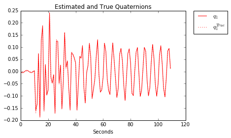

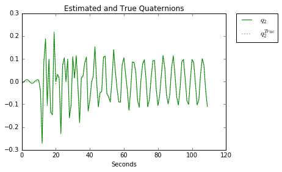

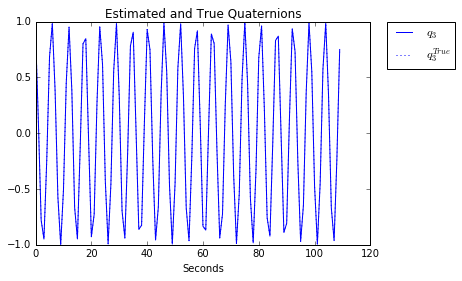

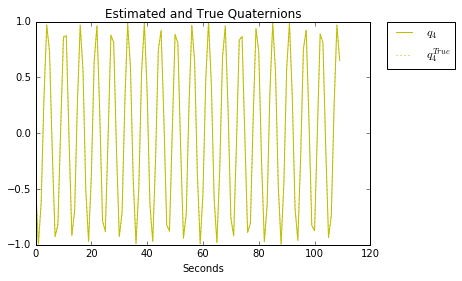

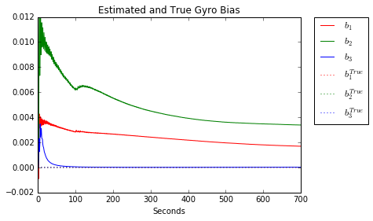

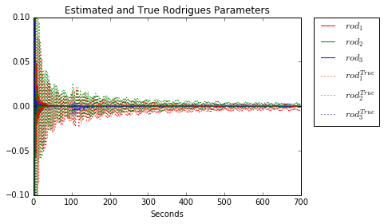

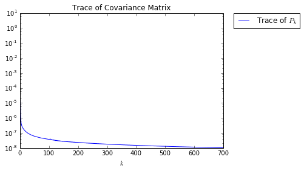

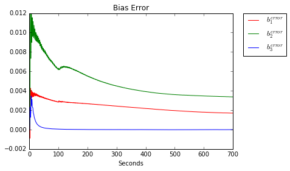

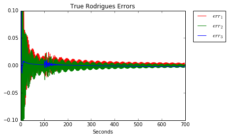

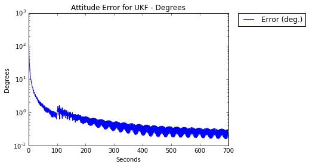

```python
plotResults(results)
```